# Biostat 203B Homework 5

Due Mar 22 @ 11:59PM

Author

Wenbo Zhao 806074910

## Predicting ICU duration

Using the ICU cohort `mimiciv_icu_cohort.rds` you built in Homework 4, develop at least three machine learning approaches (logistic regression with enet regularization, random forest, boosting, SVM, MLP, etc) plus a model stacking approach for predicting whether a patient’s ICU stay will be longer than 2 days. You should use the `los_long` variable as the outcome. You algorithms can use patient demographic information (gender, age at ICU `intime`, marital status, race), ICU admission information (first care unit), the last lab measurements before the ICU stay, and first vital measurements during ICU stay as features. You are welcome to use any feature engineering techniques you think are appropriate; but make sure to not use features that are not available at an ICU stay’s `intime`. For instance, `last_careunit` cannot be used in your algorithms.

## Data Preprocessing

1. Data preprocessing and feature engineering.

```r
library(dbplyr)
library(DBI)
library(gt)
library(gtsummary)
library(tidyverse)
library(tidymodels)
library(keras)
library(ranger)
library(stacks)
library(xgboost)
library(glmnet)
```

```r
mimic_icu_cohort <- readRDS("mimic_icu_cohort.rds")
mimic_icu_cohort <- mimic_icu_cohort |>
  select(subject_id, hadm_id, stay_id, race, insurance, marital_status, gender, age_at_intime,
  Bicarbonate, Chloride, Creatinine, Glucose, Potassium, Sodium,
  Hematocrit, white_blood_cells,
  heart_rate, non_invasive_blood_pressure_systolic,
  non_invasive_blood_pressure_diastolic,
  respiratory_rate, temperature_fahrenheit, los_long) |>
  mutate(los_long = as.factor(los_long)) |>
  print(width = Inf)
```

```
# A tibble: 73,181 × 22
   subject_id  hadm_id  stay_id race  insurance marital_status gender
        <int>    <int>    <int> <fct> <chr>     <chr>          <chr>
 1   10004113 29879900 35200789 WHITE Other     MARRIED        M
 2   10018328 23786647 31269608 WHITE Other     DIVORCED       F
 3   10019607 24546857 34178938 Other Other     SINGLE         M
 4   10023994 21824032 30439823 Other Other     SINGLE         F
 5   10028930 26238833 33941522 ASIAN Other     <NA>           M
 6   10067921 27475639 31097260 WHITE Medicare  SINGLE         F
 7   10088776 26138210 39177309 WHITE Medicare  SINGLE         F
 8   10088776 27242516 35695123 WHITE Medicare  SINGLE         F
 9   10103795 20269407 30619907 WHITE Other     MARRIED        M
10   10103795 22741814 31411464 WHITE Other     MARRIED        M
   age_at_intime Bicarbonate Chloride Creatinine Glucose Potassium Sodium
           <dbl>       <dbl>    <dbl>      <dbl>   <dbl>     <dbl>  <dbl>
```

[output cut: 47 more lines]

```r
table_summary <- tbl_summary(
  data = mimic_icu_cohort,
  by = los_long,
)
table_summary
```

| **Characteristic** | **FALSE**, N = 38,050<sup>1</sup> | **TRUE**, N = 35,131<sup>1</sup> |
| --- | --- | --- |
| subject_id | 15,002,798 (12,488,949, 17,523,219) | 14,995,832 (12,498,337, 17,496,102) |
| hadm_id | 24,949,943 (22,469,194, 27,466,877) | 24,995,222 (22,499,999, 27,473,223) |
| stay_id | 35,026,375 (32,509,262, 37,504,248) | 34,960,130 (32,470,375, 37,471,693) |
| race |  |  |
| ASIAN | 1,148 (3.0%) | 1,007 (2.9%) |
| BLACK | 4,311 (11%) | 3,649 (10%) |
| HISPANIC | 1,492 (3.9%) | 1,249 (3.6%) |
| WHITE | 25,939 (68%) | 23,630 (67%) |
| Other | 5,160 (14%) | 5,596 (16%) |
| insurance |  |  |
| Medicaid | 3,060 (8.0%) | 2,468 (7.0%) |
| Medicare | 16,489 (43%) | 16,602 (47%) |
| Other | 18,501 (49%) | 16,061 (46%) |
| marital_status |  |  |
| DIVORCED | 2,843 (8.0%) | 2,561 (7.9%) |
| MARRIED | 16,984 (48%) | 15,784 (49%) |
| SINGLE | 11,175 (31%) | 9,683 (30%) |
| WIDOWED | 4,699 (13%) | 4,339 (13%) |
| Unknown | 2,349 | 2,764 |
| gender |  |  |
| F | 17,014 (45%) | 15,349 (44%) |
| M | 21,036 (55%) | 19,782 (56%) |
| age_at_intime | 65 (53, 77) | 67 (56, 78) |
| Bicarbonate | 25.0 (22.0, 27.0) | 24.0 (21.0, 27.0) |
| Unknown | 4,270 | 4,780 |
| Chloride | 102 (98, 105) | 102 (98, 105) |
| Unknown | 4,175 | 4,708 |
| Creatinine | 1.00 (0.80, 1.40) | 1.00 (0.80, 1.60) |
| Unknown | 2,599 | 3,171 |
| Glucose | 118 (98, 153) | 122 (100, 159) |
| Unknown | 4,282 | 4,817 |
| Potassium | 4.20 (3.80, 4.60) | 4.20 (3.80, 4.70) |
| Unknown | 4,189 | 4,712 |
| Sodium | 139.0 (136.0, 141.0) | 138.0 (135.0, 141.0) |
| Unknown | 4,174 | 4,698 |
| Hematocrit | 36 (30, 40) | 35 (29, 40) |
| Unknown | 2,236 | 2,781 |
| white_blood_cells | 9.0 (6.6, 12.6) | 9.7 (7.0, 13.8) |
| Unknown | 2,272 | 2,822 |
| heart_rate | 84 (73, 98) | 87 (75, 103) |
| Unknown | 17 | 1 |
| non_invasive_blood_pressure_systolic | 122 (107, 139) | 119 (103, 137) |
| Unknown | 732 | 247 |
| non_invasive_blood_pressure_diastolic | 67 (57, 79) | 66 (55, 78) |
| Unknown | 733 | 250 |
| respiratory_rate | 18.0 (15.0, 22.0) | 19.0 (15.0, 23.0) |
| Unknown | 87 | 11 |
| temperature_fahrenheit | 98.10 (97.60, 98.60) | 98.20 (97.60, 98.80) |
| Unknown | 1,188 | 173 |

<sup>1</sup> Median (IQR); n (%)

2. Partition data into 50% training set and 50% test set. Stratify partitioning according to `los_long`. For grading purpose, sort the data by `subject_id`, `hadm_id`, and `stay_id` and use the seed `203` for the initial data split. Below is the sample code.

```r
set.seed(203)

# sort
mimiciv_icu_cohort <- mimic_icu_cohort |>
  arrange(subject_id, hadm_id, stay_id)

data_split <- initial_split(
  mimiciv_icu_cohort |> select(-subject_id, -hadm_id, -stay_id),
  # stratify by los_long
  strata = "los_long",
  prop = 0.5
  )
```

```r
train_set <- training(data_split)
dim(train_set)
```

```
[1] 36590    19
```

```r
test_set <- testing(data_split)
dim(test_set)
```

```
[1] 36591    19
```

```r
recipe <- recipe(los_long ~ ., data = train_set) %>%
  # Impute missing values
  step_impute_mean(all_numeric(), -all_outcomes()) %>%
  step_impute_mode(all_nominal(), -all_outcomes()) %>%
  # Dummy variables for categorical predictors
  step_dummy(all_nominal(), -all_outcomes()) %>%
  # Normalize numeric predictors
  step_zv(all_numeric_predictors()) %>%
  step_normalize(all_numeric(), -all_outcomes())
```

## Train and Tune Models

3. Train and tune the models using the training set.

### Logistic Regression

```r
logit_mod <-
  logistic_reg(
    penalty = tune(),
    mixture = tune()
  ) |>
  set_engine("glmnet", standardize = FALSE) |>
  print()
```

```
Logistic Regression Model Specification (classification)

Main Arguments:
  penalty = tune()
  mixture = tune()

Engine-Specific Arguments:
  standardize = FALSE

Computational engine: glmnet
```

```r
logit_wf <- workflow() |>
  add_recipe(recipe) |>
  add_model(logit_mod)
logit_wf
```

```
══ Workflow ════════════════════════════════════════════════════════════════════
Preprocessor: Recipe
Model: logistic_reg()

── Preprocessor ────────────────────────────────────────────────────────────────
5 Recipe Steps

• step_impute_mean()
• step_impute_mode()
• step_dummy()
• step_zv()
• step_normalize()

── Model ───────────────────────────────────────────────────────────────────────
Logistic Regression Model Specification (classification)

Main Arguments:
  penalty = tune()
  mixture = tune()

Engine-Specific Arguments:
  standardize = FALSE

Computational engine: glmnet
```

```r
set.seed(203)

folds <- vfold_cv(train_set, v = 5)
```

```r
logit_grid <- grid_regular(
  penalty(range = c(-6, 1)),
  mixture(),
  levels = c(50, 3)
  )
```

```r
file_path <- "logit_res.RData"

if (file.exists(file_path)) {
  load(file_path)
} else {
logit_res <-
  tune_grid(
    object = logit_wf,
    resamples = folds,
    grid = logit_grid,
    control = control_stack_grid()
  )
save(logit_res, file = file_path)
}
```

```
# A tibble: 300 × 8
      penalty mixture .metric  .estimator  mean     n std_err
        <dbl>   <dbl> <chr>    <chr>      <dbl> <int>   <dbl>
 1 0.000001         0 accuracy binary     0.565     5 0.00335
 2 0.000001         0 roc_auc  binary     0.589     5 0.00278
 3 0.00000139       0 accuracy binary     0.565     5 0.00335
 4 0.00000139       0 roc_auc  binary     0.589     5 0.00278
 5 0.00000193       0 accuracy binary     0.565     5 0.00335
 6 0.00000193       0 roc_auc  binary     0.589     5 0.00278
 7 0.00000268       0 accuracy binary     0.565     5 0.00335
 8 0.00000268       0 roc_auc  binary     0.589     5 0.00278
 9 0.00000373       0 accuracy binary     0.565     5 0.00335
10 0.00000373       0 roc_auc  binary     0.589     5 0.00278
   .config
   <chr>
 1 Preprocessor1_Model001
 2 Preprocessor1_Model001
 3 Preprocessor1_Model002
 4 Preprocessor1_Model002
 5 Preprocessor1_Model003
 6 Preprocessor1_Model003
 7 Preprocessor1_Model004
 8 Preprocessor1_Model004
 9 Preprocessor1_Model005
10 Preprocessor1_Model005
# ℹ 290 more rows
```

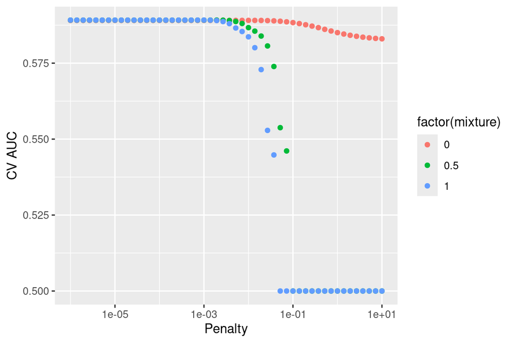

```r
logit_res |>
  # aggregate metrics from K folds
  collect_metrics() |>
  print(width = Inf) |>
  filter(.metric == "roc_auc") |>
  ggplot(mapping = aes(x = penalty, y = mean, color = factor(mixture))) +
  geom_point() +
  labs(x = "Penalty", y = "CV AUC") +
  scale_x_log10()
```

```r
best_logit <- logit_res |>
  select_best("roc_auc")
best_logit
```

```
# A tibble: 1 × 3
  penalty mixture .config
    <dbl>   <dbl> <chr>
1   0.001       1 Preprocessor1_Model122
```

### Random Forest

```r
rf_mod <-
  rand_forest(
    mode = "classification",
    # Number of predictors randomly sampled in each split
    mtry = tune(),
    # Number of trees in ensemble
    trees = tune()
  ) |>
  set_engine("ranger")
rf_mod
```

```
Random Forest Model Specification (classification)

Main Arguments:
  mtry = tune()
  trees = tune()

Computational engine: ranger
```

```r
rf_wf <- workflow() |>
  add_recipe(recipe) |>
  add_model(rf_mod)
rf_wf
```

```
══ Workflow ════════════════════════════════════════════════════════════════════
Preprocessor: Recipe
Model: rand_forest()

── Preprocessor ────────────────────────────────────────────────────────────────
5 Recipe Steps

• step_impute_mean()
• step_impute_mode()
• step_dummy()
• step_zv()
• step_normalize()

── Model ───────────────────────────────────────────────────────────────────────
Random Forest Model Specification (classification)

Main Arguments:
  mtry = tune()
  trees = tune()

Computational engine: ranger
```

```r
rf_grid <- grid_regular(
  trees(range = c(100L, 500L)),
  mtry(range = c(1L, 5L)),
  levels = c(5, 5)
  )
```

```r
file_path <- "rf_res.RData"

if (file.exists(file_path)) {
  load(file_path)
} else {
  rf_res <- tune_grid(
    object = rf_wf,
    resamples = folds,
    grid = rf_grid,
    control = control_stack_grid()
  )

  save(rf_res, file = file_path)
}
```

```
# A tibble: 50 × 8
    mtry trees .metric  .estimator  mean     n std_err .config
   <int> <int> <chr>    <chr>      <dbl> <int>   <dbl> <chr>
 1     1   100 accuracy binary     0.576     5 0.00360 Preprocessor1_Model01
 2     1   100 roc_auc  binary     0.610     5 0.00172 Preprocessor1_Model01
 3     1   200 accuracy binary     0.578     5 0.00452 Preprocessor1_Model02
 4     1   200 roc_auc  binary     0.613     5 0.00306 Preprocessor1_Model02
 5     1   300 accuracy binary     0.577     5 0.00222 Preprocessor1_Model03
 6     1   300 roc_auc  binary     0.614     5 0.00215 Preprocessor1_Model03
 7     1   400 accuracy binary     0.581     5 0.00365 Preprocessor1_Model04
 8     1   400 roc_auc  binary     0.616     5 0.00349 Preprocessor1_Model04
 9     1   500 accuracy binary     0.580     5 0.00318 Preprocessor1_Model05
10     1   500 roc_auc  binary     0.616     5 0.00260 Preprocessor1_Model05
# ℹ 40 more rows
```

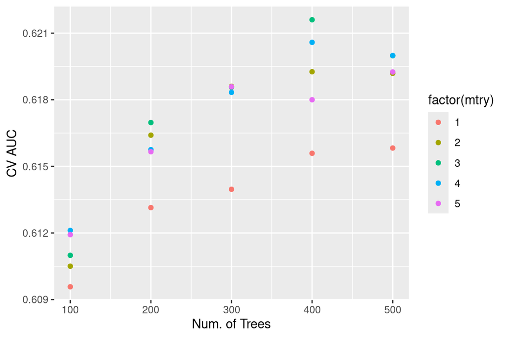

```r
rf_res |>
  collect_metrics() |>
  print(width = Inf) |>
  filter(.metric == "roc_auc") |>
  ggplot(mapping = aes(x = trees, y = mean, color = factor(mtry))) +
  geom_point() +
  # geom_line() +
  labs(x = "Num. of Trees", y = "CV AUC")
```

```r
best_rf <- rf_res |>
  select_best("roc_auc")
best_rf
```

```
# A tibble: 1 × 3
   mtry trees .config
  <int> <int> <chr>
1     3   400 Preprocessor1_Model14
```

### Boost

```r
gb_mod <-
  boost_tree(
    mode = "classification",
    trees = 1000,
    tree_depth = tune(),
    learn_rate = tune()
  ) |>
  set_engine("xgboost")
gb_mod
```

```
Boosted Tree Model Specification (classification)

Main Arguments:
  trees = 1000
  tree_depth = tune()
  learn_rate = tune()

Computational engine: xgboost
```

```r
gb_wf <- workflow() |>
  add_recipe(recipe) |>
  add_model(gb_mod)
gb_wf
```

```
══ Workflow ════════════════════════════════════════════════════════════════════
Preprocessor: Recipe
Model: boost_tree()

── Preprocessor ────────────────────────────────────────────────────────────────
5 Recipe Steps

• step_impute_mean()
• step_impute_mode()
• step_dummy()
• step_zv()
• step_normalize()

── Model ───────────────────────────────────────────────────────────────────────
Boosted Tree Model Specification (classification)

Main Arguments:
  trees = 1000
  tree_depth = tune()
  learn_rate = tune()

Computational engine: xgboost
```

```r
gb_grid <- grid_regular(
  tree_depth(range = c(1L, 3L)),
  learn_rate(range = c(-5, 2), trans = log10_trans()),
  levels = c(3, 10)
  )
```

```r
file_path <- "gb_res.RData"

if (file.exists(file_path)) {
  load(file_path)
} else {
  gb_res <- tune_grid(
    object = gb_wf,
    resamples = folds,
    grid = gb_grid,
    control = control_stack_grid()
  )

  save(gb_res, file = file_path)
}
```

```
# A tibble: 60 × 8
   tree_depth learn_rate .metric  .estimator  mean     n std_err
        <int>      <dbl> <chr>    <chr>      <dbl> <int>   <dbl>
 1          1  0.00001   accuracy binary     0.535     5 0.00295
 2          1  0.00001   roc_auc  binary     0.530     5 0.00615
 3          2  0.00001   accuracy binary     0.537     5 0.00486
 4          2  0.00001   roc_auc  binary     0.552     5 0.00636
 5          3  0.00001   accuracy binary     0.547     5 0.00616
 6          3  0.00001   roc_auc  binary     0.564     5 0.00598
 7          1  0.0000599 accuracy binary     0.536     5 0.00361
 8          1  0.0000599 roc_auc  binary     0.541     5 0.00709
 9          2  0.0000599 accuracy binary     0.543     5 0.00502
10          2  0.0000599 roc_auc  binary     0.563     5 0.00688
   .config
   <chr>
 1 Preprocessor1_Model01
 2 Preprocessor1_Model01
 3 Preprocessor1_Model02
 4 Preprocessor1_Model02
 5 Preprocessor1_Model03
 6 Preprocessor1_Model03
 7 Preprocessor1_Model04
 8 Preprocessor1_Model04
 9 Preprocessor1_Model05
10 Preprocessor1_Model05
# ℹ 50 more rows
```

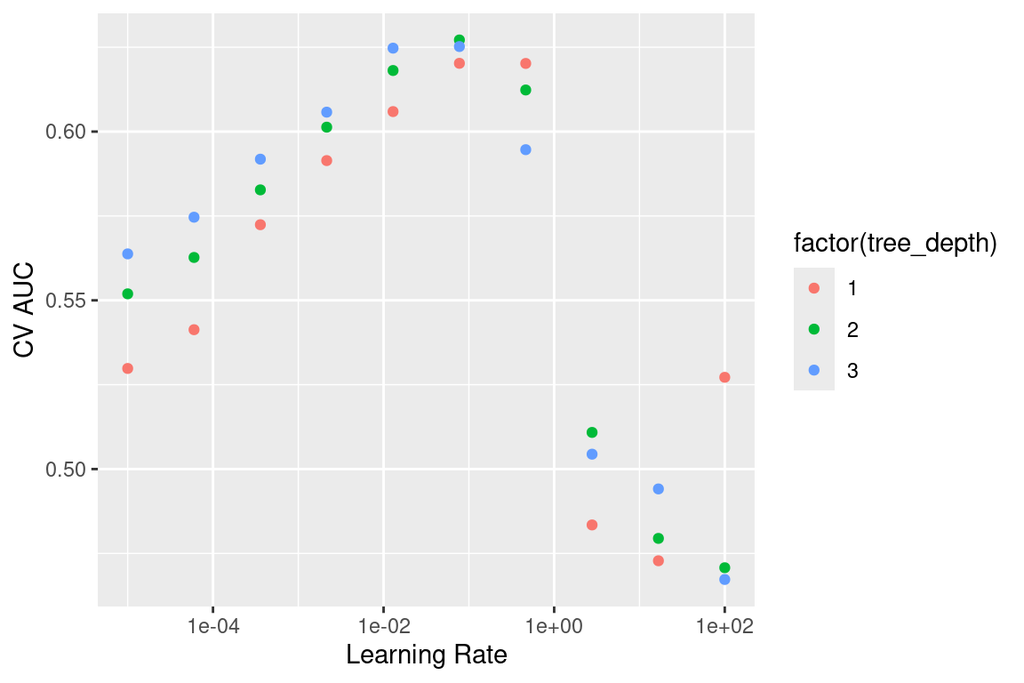

```r
gb_res |>
  collect_metrics() |>
  print(width = Inf) |>
  filter(.metric == "roc_auc") |>
  ggplot(mapping = aes(x = learn_rate, y = mean, color = factor(tree_depth))) +
  geom_point() +
  labs(x = "Learning Rate", y = "CV AUC") +
  scale_x_log10()
```

```r
best_gb <- gb_res |>
  select_best("roc_auc")
best_gb
```

```
# A tibble: 1 × 3
  tree_depth learn_rate .config
       <int>      <dbl> <chr>
1          2     0.0774 Preprocessor1_Model17
```

### Model Stacking

```r
file_path <- "icu_model_st.RData"

if (file.exists(file_path)) {
  load(file_path)
} else {
icu_model_st <-
  # initialize the stack
  stacks() |>
  # add candidate members
  add_candidates(logit_res) |>
  add_candidates(rf_res) |>
  add_candidates(gb_res) |>
  # determine how to combine their predictions
  blend_predictions(
    penalty = 10^(-6:2),
    metrics = c("roc_auc")
    ) |>
  # fit the candidates with nonzero stacking coefficients
  fit_members()
save(icu_model_st, file = file_path)
}
```

```r
icu_model_st
```

```
# A tibble: 10 × 3
   member                 type        weight
   <chr>                  <chr>        <dbl>
 1 .pred_TRUE_gb_res_1_17 boost_tree  1.29
 2 .pred_TRUE_rf_res_1_14 rand_forest 1.29
 3 .pred_TRUE_rf_res_1_19 rand_forest 0.756
 4 .pred_TRUE_gb_res_1_18 boost_tree  0.639
 5 .pred_TRUE_gb_res_1_19 boost_tree  0.543
 6 .pred_TRUE_rf_res_1_23 rand_forest 0.220
 7 .pred_TRUE_gb_res_1_20 boost_tree  0.142
 8 .pred_TRUE_gb_res_1_25 boost_tree  0.0610
 9 .pred_TRUE_gb_res_1_30 boost_tree  0.0486
10 .pred_TRUE_gb_res_1_27 boost_tree  0.0308
```

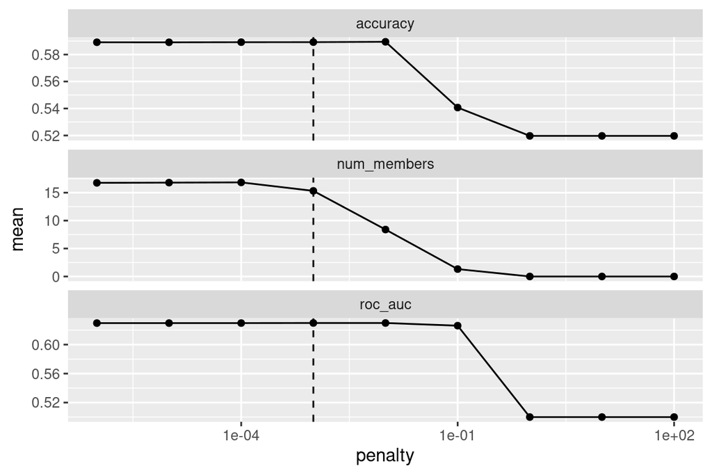

```r
autoplot(icu_model_st)
```

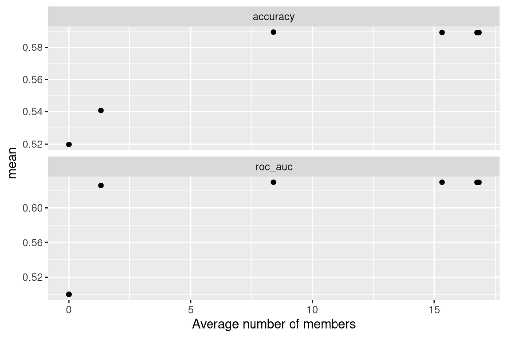

```r
autoplot(icu_model_st, type = "members")
```

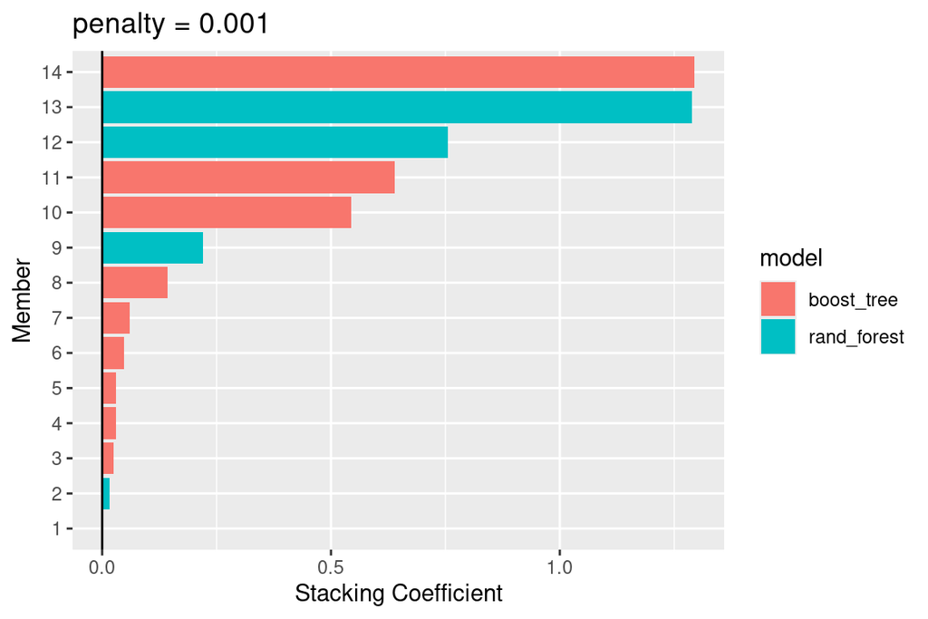

```r
autoplot(icu_model_st, type = "weights")
```

## Model Performance

4. Compare model classification performance on the test set. Report both the area under ROC curve and accuracy for each machine learning algorithm and the model stacking. Interpret the results. What are the most important features in predicting long ICU stays? How do the models compare in terms of performance and interpretability?

### Logstic Regression

```r
logit_wf_best <- logit_wf |>
  finalize_workflow(best_logit)

logit_best_fit <-
  logit_wf_best |>
  last_fit(data_split)
logit_best_fit
```

```
# Resampling results
# Manual resampling
# A tibble: 1 × 6
  splits                id             .metrics .notes   .predictions .workflow
  <list>                <chr>          <list>   <list>   <list>       <list>
1 <split [36590/36591]> train/test sp… <tibble> <tibble> <tibble>     <workflow>
```

```r
# Test metrics
logit_best_fit |>
  collect_metrics()
```

```
# A tibble: 2 × 4
  .metric  .estimator .estimate .config
  <chr>    <chr>          <dbl> <chr>
1 accuracy binary         0.565 Preprocessor1_Model1
2 roc_auc  binary         0.586 Preprocessor1_Model1
```

```r
#Feature importance
fitted_workflow <- logit_best_fit$.workflow[[1]]
fitted_model <- extract_fit_parsnip(fitted_workflow)
tidy_coefficients <- tidy(fitted_model)

race_total <- tidy_coefficients  %>%
  filter(str_detect(term, "race_")) %>%
  summarise(term = "race", estimate = sum(abs(estimate)),
            penalty = first(penalty))

gender_total <- tidy_coefficients  %>%
  filter(str_detect(term, "gender_")) %>%
  summarise(term = "gender", estimate = sum(abs(estimate)),
            penalty = first(penalty))

insurance_total <- tidy_coefficients  %>%
  filter(str_detect(term, "insurance_")) %>%
  summarise(term = "insurance", estimate = sum(abs(estimate)),
            penalty = first(penalty))

marital_status_total <- tidy_coefficients  %>%
  filter(str_detect(term, "marital_status_")) %>%
  summarise(term = "marital_status", estimate = sum(abs(estimate)),
            penalty = first(penalty))

tidy_coefficients <- tidy_coefficients %>%
  filter(!str_detect(term, "race_"), !str_detect(term, "gender_"),
         !str_detect(term, "insurance_"),
         !str_detect(term, "marital_status_")) %>%
  bind_rows(race_total, gender_total,
            insurance_total, marital_status_total) %>%
  mutate(estimate = abs(estimate)) %>%
  arrange(desc(estimate))

tidy_coefficients
```

```
# A tibble: 19 × 3
   term                                  estimate penalty
   <chr>                                    <dbl>   <dbl>
 1 heart_rate                              0.135    0.001
 2 age_at_intime                           0.103    0.001
 3 non_invasive_blood_pressure_systolic    0.0974   0.001
 4 white_blood_cells                       0.0938   0.001
 5 Hematocrit                              0.0906   0.001
 6 Chloride                                0.0882   0.001
 7 respiratory_rate                        0.0868   0.001
 8 (Intercept)                             0.0801   0.001
 9 Sodium                                  0.0763   0.001
10 race                                    0.0745   0.001
11 marital_status                          0.0543   0.001
12 insurance                               0.0337   0.001
13 Creatinine                              0.0316   0.001
14 Potassium                               0.0314   0.001
15 temperature_fahrenheit                  0.0270   0.001
16 gender                                  0.0236   0.001
17 Bicarbonate                             0        0.001
18 Glucose                                 0        0.001
19 non_invasive_blood_pressure_diastolic   0        0.001
```

### Random Forest

```r
rf_wf_best <- rf_wf |>
  finalize_workflow(best_rf)

rf_best_fit <-
  rf_wf_best |>
  last_fit(data_split)
rf_best_fit
```

```
# Resampling results
# Manual resampling
# A tibble: 1 × 6
  splits                id             .metrics .notes   .predictions .workflow
  <list>                <chr>          <list>   <list>   <list>       <list>
1 <split [36590/36591]> train/test sp… <tibble> <tibble> <tibble>     <workflow>
```

```r
rf_best_fit |>
  collect_metrics()
```

```
# A tibble: 2 × 4
  .metric  .estimator .estimate .config
  <chr>    <chr>          <dbl> <chr>
1 accuracy binary         0.587 Preprocessor1_Model1
2 roc_auc  binary         0.621 Preprocessor1_Model1
```

### Boost

```r
gb_best_wf <- gb_wf |>
  finalize_workflow(best_gb)

gb_best_fit <-
  gb_best_wf |>
  last_fit(data_split)
```

```r
gb_best_fit |>
  collect_metrics()
```

```
# A tibble: 2 × 4
  .metric  .estimator .estimate .config
  <chr>    <chr>          <dbl> <chr>
1 accuracy binary         0.591 Preprocessor1_Model1
2 roc_auc  binary         0.629 Preprocessor1_Model1
```

### Model Stacking

```r
icu_pred <- test_set %>%
  bind_cols(predict(icu_model_st, ., type = "prob")) %>%
  print(width = Inf)
```

```
# A tibble: 36,591 × 21
   race  insurance marital_status gender age_at_intime Bicarbonate Chloride
   <fct> <chr>     <chr>          <chr>          <dbl>       <dbl>    <dbl>
 1 WHITE Medicaid  WIDOWED        F                 52          25       95
 2 WHITE Other     MARRIED        F                 55          22      108
 3 WHITE Other     MARRIED        F                 55          30      104
 4 WHITE Other     MARRIED        F                 46          NA       98
 5 Other Medicare  SINGLE         F                 57          24      102
 6 WHITE Other     MARRIED        F                 81          24      105
 7 WHITE Medicare  WIDOWED        F                 81          25       89
 8 WHITE Medicare  WIDOWED        F                 81          27      111
 9 WHITE Medicare  WIDOWED        M                 90          23      102
10 Other Medicare  MARRIED        M                 81          NA       NA
   Creatinine Glucose Potassium Sodium Hematocrit white_blood_cells heart_rate
        <dbl>   <dbl>     <dbl>  <dbl>      <dbl>             <dbl>      <dbl>
```

[output cut: 35 more lines]

```r
auc_result <- roc_auc(
  icu_pred,
  truth = los_long,
  contains(".pred_FALSE")
)

print(auc_result)
```

```
# A tibble: 1 × 3
  .metric .estimator .estimate
  <chr>   <chr>          <dbl>
1 roc_auc binary         0.634
```

```r
icu_pred$.pred_class <- ifelse(icu_pred$.pred_TRUE > 0.5, "TRUE", "FALSE")
icu_pred <- icu_pred |>
  mutate(.pred_class = as.factor(.pred_class))
accuracy_result <- accuracy(
  data = icu_pred,
  truth = los_long,
  estimate = .pred_class
)

print(accuracy_result)
```

```
# A tibble: 1 × 3
  .metric  .estimator .estimate
  <chr>    <chr>          <dbl>
1 accuracy binary         0.596
```

### Model Performacne Comparision

```r
logit_metrics <- logit_best_fit |>
  collect_metrics() %>%
  filter(.metric %in% c("roc_auc", "accuracy"))

rf_metrics <- rf_best_fit |>
  collect_metrics() %>%
  filter(.metric %in% c("roc_auc", "accuracy"))

gb_metrics <- gb_best_fit |>
  collect_metrics() %>%
  filter(.metric %in% c("roc_auc", "accuracy"))

stacking_auc <- auc_result$.estimate
stacking_accuracy <- accuracy_result$.estimate

model_performance <- tibble(
  Model = c("Logistic Regression", "Random Forest", "Boost", "Stacking Model"),
  AUC = c(logit_metrics$.estimate[logit_metrics$.metric == "roc_auc"],
          rf_metrics$.estimate[rf_metrics$.metric == "roc_auc"],
          gb_metrics$.estimate[gb_metrics$.metric == "roc_auc"],
          stacking_auc),
  Accuracy = c(logit_metrics$.estimate[logit_metrics$.metric == "accuracy"],
               rf_metrics$.estimate[rf_metrics$.metric == "accuracy"],
               gb_metrics$.estimate[gb_metrics$.metric == "accuracy"],
               stacking_accuracy)
)

print(model_performance)
```

```
# A tibble: 4 × 3
  Model                 AUC Accuracy
  <chr>               <dbl>    <dbl>
1 Logistic Regression 0.586    0.565
2 Random Forest       0.621    0.587
3 Boost               0.629    0.591
4 Stacking Model      0.634    0.596
```

**Model Performance Ranking:** The Stacking Model performs the best in terms of both AUC and accuracy, followed by the Boosting Model, Random Forest, and Logistic Regression. This ranking indicates that combining multiple models through stacking effectively leverages their individual strengths, leading to improved predictive performance.

In terms of performance metrics (AUC and accuracy), all models have some ability to distinguish between classes, but none are exceptionally high. Besides, all models perform relatively close to each other, with only a marginal difference between the best and worst.

**Feature Importance and Interpretability:** According to the feature importance analysis based on Logistic Regression model, the most significant features when deciding if a patient will stay in ICU for more than two days are `heart_rate`, `age_at_intime`, `non_invasive_blood_pressure_systolic`, `white_blood_cells` and `Hematocrit`. While features like `Bicarbonate`, `Glucose` and `non_invasive_blood_pressure_diastolic` basically have no effcet on the ICU stay.

In terms of interpretability, as the model becomes more complex, it will become less interpretable but offer a better performance. Logistic Regression, despite being the least accurate, offers the highest interpretability. Random Forest and Boosting Models, while more accurate, are less interpretable due to their complexity. The Stacking Model, despite its superior performance, is the least interpretable as it combines predictions from multiple models.